# Taller tuberias en TensorFlow - Parte 2

### Autor: Samuel Mesa

### Fecha: 1 de mayo de 2021

**Objetivo**: Un cuaderno en donde ustedes harán el entubamiento de un conjunto de datos asociado a su proyecto. Para este, ustedes revisan el segundo cuaderno y completan detalles con los enlaces abajo. El entregable es preferiblemente el entubamiento que usted usa o usará en su proyecto.¶

### Cargar librerias

```python
import datetime
import os, glob
import numpy as np
import seaborn as sns
import geopandas as gpd
import pandas as pd
import imageio
from pyspatialml import Raster
import matplotlib.pyplot as plt
from sklearn.preprocessing import StandardScaler
from sklearn.pipeline import Pipeline
import tensorflow as tf
from tensorflow.keras.layers import Dense, Dropout
from tensorflow.keras.models import Sequential
from sklearn.impute import SimpleImputer
from tensorflow.keras.wrappers.scikit_learn import KerasClassifier
from tensorflow.keras.callbacks import CSVLogger, RemoteMonitor
from sklearn.model_selection import train_test_split
from sklearn.neighbors import KNeighborsClassifier
from sklearn.metrics import accuracy_score, precision_score, recall_score, confusion_matrix
import earthpy.plot as ep
import earthpy.spatial as es
```

### Realizar el cargue de imágenes y las áreas de enetrenamiento

Bandas a seleccionar de la imagen de entrada de SENTINEL-2, con remuestreo a 10 m de resolución espacial

1. B2 (Blue)
2. B3 (Green)
3. B4 (Red)
4. B5 (Veg. red edge)
5. B6 (Veg. red edge)
6. B7 (Veg. red edge)
7. B8 (NIR)
8. B8A (Narrow NIR)
9. B11 (SWIR)
10. B12 (SWIR)

La estructura de directorios es el siguiente.

- [nombre_proyecto]
  - shapes: shapes de aoi y capas de superposición
  - models: Almacena el modelo
  - sources: imágenes satelitales de entrada
  - results: resultados de las clasificación
  - logs: logs del entrenamiento
  - figures: imágenes y figuras

```python
path_project = "./tunjo/"
path_sources = os.path.join(path_project, "sources")
path_shapes = os.path.join(path_project, "shapes")
path_results = os.path.join(path_project, "results")
path_logs = os.path.join(path_project, "logs")
path_figures = os.path.join(path_project, "figures")
path_models = os.path.join(path_project, "models")
list_paths = [path_results, path_figures, path_models, path_logs]

# Crear directorios temporales

for path in list_paths:
    try:
        os.mkdir(path)
    except FileExistsError:
        print("Directorio ya existe: ", os.path.basename(path))

# Defina la imagen de entrada
img_train = '20210309T152639_20210309T152638_T18NWL.tif'
img_file = os.path.join(path_sources, img_train)
aoi_file = os.path.join(path_shapes, 'aoi.geojson') # Formato geográfico
manzana_file = os.path.join(path_shapes, 'manzana.geojson') # Formato geográfico
img_name = img_train.split('_')[0]

# Cargar la imagen como un objeto Raster Dataframe y el shape de aoi como Geodaataframe
stack = Raster(img_file)
training = gpd.read_file(aoi_file)
manzana = gpd.read_file(manzana_file)

bandsio = ['B2', 'B3', 'B4', 'B5', 'B6', 'B7', 'B8', 'B8A', 'B11', 'B12']
bandsio_names = ['B2 (Blue)', 'B3 (Green)', 'B4 (Red)', 'B5 (Veg. red edge)',
               'B6 (Veg. red edge)', 'B7 (Veg. red edge)', 'B8 (NIR)',
               'B8A (Narrow NIR)', 'B11 (SWIR)', 'B12 (SWIR)']

# Mapea los nombres de bandas de entrada
[stack.rename({name: bandsio[idx]}, in_place=True) for idx, name in enumerate(stack.names)]
extent = es.rio.plot.plotting_extent(stack)
```

```
Directorio ya existe:  results
Directorio ya existe:  figures
Directorio ya existe:  models
Directorio ya existe:  logs
```

## Se define la selección de bandas de entrenamineto y salida para todo el proceso

```python
bandsout = ['B2', 'B3', 'B4', 'B5', 'B6', 'B7', 'B8', 'B8A', 'B11', 'B12']
bandsout_names = ['B2 (Blue)', 'B3 (Green)', 'B4 (Red)', 'B5 (Veg. red edge)',
               'B6 (Veg. red edge)', 'B7 (Veg. red edge)', 'B8 (NIR)',
               'B8A (Narrow NIR)', 'B11 (SWIR)', 'B12 (SWIR)']
```

## Anáisis exploratorio de datos

Despliegue de imágenes y análisis exploratorio

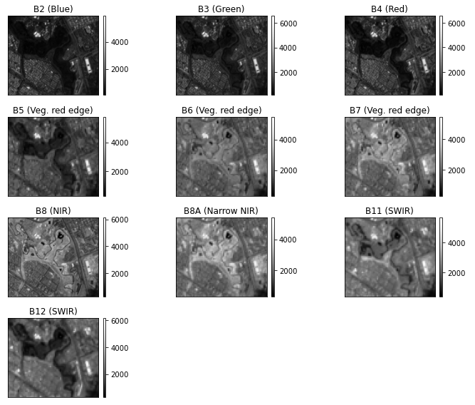

```
array([[<AxesSubplot:title={'center':'B2 (Blue)'}>,
        <AxesSubplot:title={'center':'B3 (Green)'}>,
        <AxesSubplot:title={'center':'B4 (Red)'}>],
       [<AxesSubplot:title={'center':'B5 (Veg. red edge)'}>,
        <AxesSubplot:title={'center':'B6 (Veg. red edge)'}>,
        <AxesSubplot:title={'center':'B7 (Veg. red edge)'}>],
       [<AxesSubplot:title={'center':'B8 (NIR)'}>,
        <AxesSubplot:title={'center':'B8A (Narrow NIR)'}>,
        <AxesSubplot:title={'center':'B11 (SWIR)'}>],
       [<AxesSubplot:title={'center':'B12 (SWIR)'}>, <AxesSubplot:>,
        <AxesSubplot:>]], dtype=object)
```

```python
# Despliegue los canales  imágenes
ep.plot_bands(stack[bandsout].read(), title=bandsout_names, figsize=(10, 8))
```

```
(<Figure size 864x864 with 10 Axes>,
 array([[<AxesSubplot:title={'center':'B2 (Blue)'}, ylabel='Reflectancia'>,
         <AxesSubplot:title={'center':'B3 (Green)'}, ylabel='Reflectancia'>],
        [<AxesSubplot:title={'center':'B4 (Red)'}, ylabel='Reflectancia'>,
         <AxesSubplot:title={'center':'B5 (Veg. red edge)'}, ylabel='Reflectancia'>],
        [<AxesSubplot:title={'center':'B6 (Veg. red edge)'}, ylabel='Reflectancia'>,
         <AxesSubplot:title={'center':'B7 (Veg. red edge)'}, ylabel='Reflectancia'>],
        [<AxesSubplot:title={'center':'B8 (NIR)'}, ylabel='Reflectancia'>,
         <AxesSubplot:title={'center':'B8A (Narrow NIR)'}, ylabel='Reflectancia'>],
        [<AxesSubplot:title={'center':'B11 (SWIR)'}, ylabel='Reflectancia'>,
         <AxesSubplot:title={'center':'B12 (SWIR)'}, ylabel='Reflectancia'>]],
       dtype=object))
```

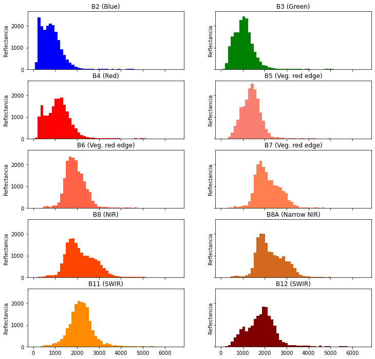

```python
# Histogramas por bandas

colors_list = ["Blue", "Green", "Red", "Salmon", "Tomato", "Coral", "Orangered",
               "Chocolate","Darkorange","Maroon"]

ep.hist(stack[bandsout].read(), colors=colors_list, title=bandsout_names,
        ylabel='Reflectancia', bins=50, cols=2)
```

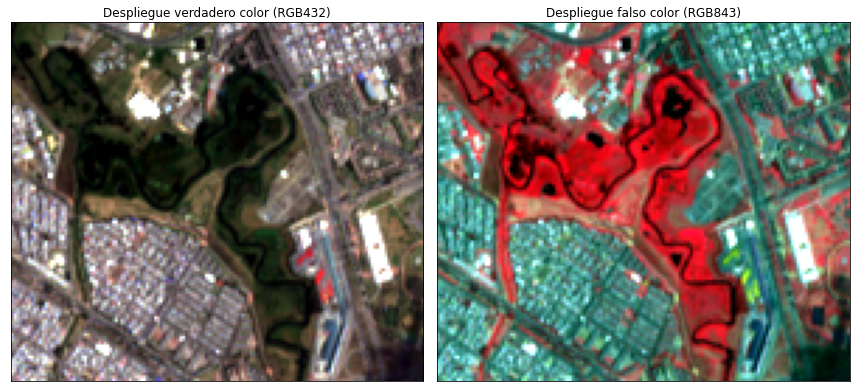

```python
# Despliegue composición de color

rgb432 = stack[['B4','B3', 'B2']].read()
rgb843 = stack[['B8','B4', 'B3']].read()

fig, (ax1, ax2) = plt.subplots(1, 2, figsize=(12, 6))

ep.plot_rgb(rgb432, ax=ax1, title='Despliegue verdadero color (RGB432)', stretch=True)
ep.plot_rgb(rgb843, ax=ax2, title='Despliegue falso color (RGB843)', stretch=True)
plt.tight_layout()
plt.show()
```

Despliegue de las áreas de entrenamiento

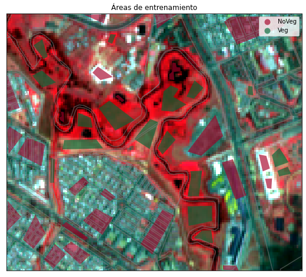

```python
fig, ax = plt.subplots(figsize=(9, 9))
ep.plot_rgb(rgb843, ax=ax, stretch=True, extent=extent)
manzana.boundary.plot(ax=ax, color='grey', alpha=0.5,)
training.plot(column="label", cmap='RdYlGn', ax=ax, legend=True,  alpha=0.65, categorical=True)
ax.axis('on')
plt.title('Áreas de entrenamiento')
plt.show()
```

```python
# Convertir los pixeles a un dataframe de pandas

df = stack[bandsout].to_pandas()
df.head()
```

|  | x | y | B2 | B3 | B4 | B5 | B6 | B7 | B8 | B8A | B11 | B12 |
| --- | --- | --- | --- | --- | --- | --- | --- | --- | --- | --- | --- | --- |
| 0 | 594300.000000 | 506180.0 | 306.0 | 552.0 | 521.0 | 764.0 | 1610.0 | 2268.0 | 2382.0 | 2557.0 | 1628.0 | 1033.0 |
| 1 | 594310.068493 | 506180.0 | 248.0 | 354.0 | 308.0 | 764.0 | 1610.0 | 2268.0 | 1790.0 | 2557.0 | 1628.0 | 1033.0 |
| 2 | 594320.136986 | 506180.0 | 290.0 | 575.0 | 449.0 | 973.0 | 2427.0 | 2693.0 | 2808.0 | 2838.0 | 1856.0 | 1064.0 |
| 3 | 594330.205479 | 506180.0 | 334.0 | 666.0 | 514.0 | 973.0 | 2427.0 | 2693.0 | 3164.0 | 2838.0 | 1856.0 | 1064.0 |
| 4 | 594340.273973 | 506180.0 | 363.0 | 743.0 | 607.0 | 1132.0 | 2492.0 | 2963.0 | 2900.0 | 3366.0 | 2057.0 | 1234.0 |

```python
print('Las columnas son: ', df.columns)
print('El tamaño´ del dataframe: ', df.shape)
print(df[bandsout].describe().T)
```

```
Las columnas son:  Index(['x', 'y', 'B2', 'B3', 'B4', 'B5', 'B6', 'B7', 'B8', 'B8A', 'B11',
       'B12'],
      dtype='object')
El tamaño´ del dataframe:  (18816, 12)
       count         mean         std    min     25%     50%      75%     max
B2   18816.0   836.277583  530.597252   64.0   454.0   769.0  1080.00  5908.0
B3   18816.0  1066.075999  532.072826  133.0   722.0  1017.0  1284.00  6556.0
B4   18816.0  1138.359800  609.381740  114.0   714.0  1116.0  1456.00  6544.0
B5   18816.0  1406.380102  503.829649  308.0  1094.0  1391.0  1648.00  5772.0
B6   18816.0  1920.350872  486.753114  319.0  1608.0  1870.5  2184.25  5491.0
B7   18816.0  2132.852572  568.216038  326.0  1734.0  2036.0  2496.25  5425.0
B8   18816.0  2153.274979  655.596387  273.0  1678.0  2034.0  2602.00  6136.0
B8A  18816.0  2261.102891  617.403156  307.0  1804.0  2126.0  2699.00  5409.0
B11  18816.0  2173.782100  563.845698  392.0  1848.0  2155.5  2457.00  5675.0
B12  18816.0  1824.713010  675.126151  277.0  1379.0  1856.0  2210.00  6132.0
```

```python
# Correlacción de las bandas

correlation_data = df.iloc[:,2:].corr()
correlation_data.style.background_gradient(cmap='coolwarm', axis=None)
```

|  | B2 | B3 | B4 | B5 | B6 | B7 | B8 | B8A | B11 | B12 |
| --- | --- | --- | --- | --- | --- | --- | --- | --- | --- | --- |
| B2 | 1.000000 | 0.972844 | 0.952348 | 0.854090 | 0.278757 | 0.065329 | 0.073105 | -0.026923 | 0.611698 | 0.808887 |
| B3 | 0.972844 | 1.000000 | 0.971263 | 0.895550 | 0.395855 | 0.185262 | 0.199752 | 0.092389 | 0.688329 | 0.822943 |
| B4 | 0.952348 | 0.971263 | 1.000000 | 0.910007 | 0.340398 | 0.118602 | 0.120648 | 0.022096 | 0.695865 | 0.843949 |
| B5 | 0.854090 | 0.895550 | 0.910007 | 1.000000 | 0.557775 | 0.339255 | 0.275435 | 0.245003 | 0.833778 | 0.883065 |
| B6 | 0.278757 | 0.395855 | 0.340398 | 0.557775 | 1.000000 | 0.948065 | 0.872684 | 0.913443 | 0.687255 | 0.358862 |
| B7 | 0.065329 | 0.185262 | 0.118602 | 0.339255 | 0.948065 | 1.000000 | 0.915475 | 0.976660 | 0.538896 | 0.155824 |
| B8 | 0.073105 | 0.199752 | 0.120648 | 0.275435 | 0.872684 | 0.915475 | 1.000000 | 0.917705 | 0.486189 | 0.119533 |
| B8A | -0.026923 | 0.092389 | 0.022096 | 0.245003 | 0.913443 | 0.976660 | 0.917705 | 1.000000 | 0.502150 | 0.097535 |
| B11 | 0.611698 | 0.688329 | 0.695865 | 0.833778 | 0.687255 | 0.538896 | 0.486189 | 0.502150 | 1.000000 | 0.868317 |
| B12 | 0.808887 | 0.822943 | 0.843949 | 0.883065 | 0.358862 | 0.155824 | 0.119533 | 0.097535 | 0.868317 | 1.000000 |

```python
# Extraer información de las bandas con la áreas de entrenamiento

df_shape = stack[bandsout].extract_vector(training)

df_shape = df_shape.merge(
    right=training.loc[:, ["label", "id"]],
    left_on="geometry_idx",
    right_on="index",
    right_index=True
)

df_shape = df_shape.dropna()
```

```python
# Descripcion de los datos para las areas de entrenamineto

print('Total canales espectrales: ',  df_shape.columns)
print('Tamaño de entrenamiento: ', df_shape.shape)
print(df[bandsout].describe().T)
```

```
Total canales espectrales:  Index(['B2', 'B3', 'B4', 'B5', 'B6', 'B7', 'B8', 'B8A', 'B11', 'B12',
       'geometry', 'label', 'id'],
      dtype='object')
Tamaño de entrenamiento:  (3370, 13)
       count         mean         std    min     25%     50%      75%     max
B2   18816.0   836.277583  530.597252   64.0   454.0   769.0  1080.00  5908.0
B3   18816.0  1066.075999  532.072826  133.0   722.0  1017.0  1284.00  6556.0
B4   18816.0  1138.359800  609.381740  114.0   714.0  1116.0  1456.00  6544.0
B5   18816.0  1406.380102  503.829649  308.0  1094.0  1391.0  1648.00  5772.0
B6   18816.0  1920.350872  486.753114  319.0  1608.0  1870.5  2184.25  5491.0
B7   18816.0  2132.852572  568.216038  326.0  1734.0  2036.0  2496.25  5425.0
B8   18816.0  2153.274979  655.596387  273.0  1678.0  2034.0  2602.00  6136.0
B8A  18816.0  2261.102891  617.403156  307.0  1804.0  2126.0  2699.00  5409.0
B11  18816.0  2173.782100  563.845698  392.0  1848.0  2155.5  2457.00  5675.0
B12  18816.0  1824.713010  675.126151  277.0  1379.0  1856.0  2210.00  6132.0
```

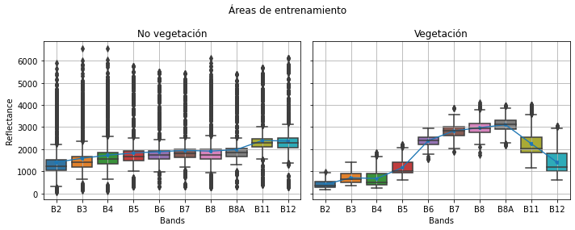

```python
fig, axes = plt.subplots(1,2, figsize=(10,4), sharey=True, sharex=True)
plt.suptitle("Áreas de entrenamiento")
axes[0].set_title('No vegetación')
axes[1].set_title('Vegetación')
axes[0].set_xlabel('Bands')
axes[0].set_ylabel('Reflectance')
axes[1].set_xlabel('Bands')
sns.pointplot(data=df_shape[df_shape['id'] == 0][bandsout], ax=axes[0],
              scale=0.5, estimator=np.mean)
sns.boxplot(data=df_shape[df_shape['id'] == 0][bandsout], ax=axes[0])
sns.pointplot(data=df_shape[df_shape['id'] == 1][bandsout], ax=axes[1],
              scale=0.5, estimator=np.mean)
sns.boxplot(data=df_shape[df_shape['id'] == 1][bandsout], ax=axes[1])
axes[0].grid()
axes[1].grid()
plt.tight_layout()
fig.show()
```

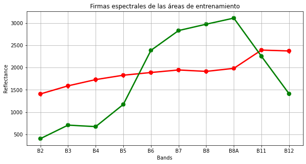

```python
fig, ax = plt.subplots(figsize=(10,5), sharey=True, sharex=True)
ax.set_title('Firmas espectrales de las áreas de entrenamiento')
ax.set_xlabel('Bands')
ax.set_ylabel('Reflectance')
sns.pointplot(data=df_shape[df_shape['id'] == 0][bandsout], ax=ax,
              scale=1, estimator=np.mean, color='red')
sns.pointplot(data=df_shape[df_shape['id'] == 1][bandsout], ax=ax,
              scale=1, estimator=np.mean, color='green')
ax.grid()
fig.show()
```

## Entrenamiento de la red neuronal

Dividir las areas de entrenamineto y validación

```python
#bands = ['B2', 'B3', 'B4', 'B7']

X = df_shape[bandsout].values
y = df_shape["id"].values

X_train, X_test, y_train, y_test = train_test_split(X, y, test_size=0.2, random_state=123)
```

```python
# Logs y callbacks para el entrenamiento

timename = datetime.datetime.now().strftime("%Y%m%d-%H%M%S")

log_csv = os.path.join(path_logs, f"log_{img_name}-{timename}.csv")
model_h5 = os.path.join(path_models, f"model_{img_name}-{timename}.h5")
imgkeras_classification = os.path.join(path_results, f"classkeras_{img_name}-{timename}.tif")
imgkeras_probability = os.path.join(path_results, f"probkeras_{img_name}-{timename}.tif")
imgkneig_classification = os.path.join(path_results, f"classkneig_{img_name}-{timename}.tif")
imgkneig_probability = os.path.join(path_results, f"probkneig_{img_name}-{timename}.tif")
fig_model = os.path.join(path_figures, f"train_{img_name}-{timename}.png")
movie_classkeras = os.path.join(path_figures, f"movie_classkeras_{timename}.gif")

call_save_model = tf.keras.callbacks.ModelCheckpoint(
    model_h5, monitor='val_loss', verbose=0, save_best_only=False,
    save_weights_only=False, mode='auto', save_freq='epoch', options=None
)

call_tensorboard = tf.keras.callbacks.TensorBoard(
    log_dir='./logs', histogram_freq=1, write_graph=True, write_images=True,
    update_freq='epoch', profile_batch=2, embeddings_freq=0,
    embeddings_metadata=True
)

call_csv = CSVLogger(log_csv, separator=",", append=False)

call_remote = RemoteMonitor(
    root='http://localhost:9000',
)
```

```python
# Crear la funcion model de keras

def create_keras_model(layer1_units, layer2_units, dropout_rate, l2_regularization):
    model = Sequential([
        ## Adiciona capas una por una
        Dense(units=layer1_units, activation='relu', input_shape=(len(bandsout),)),
        # Adding dropout to prevent overfitting (regularización)
        Dropout(dropout_rate), # 10% out in each epoc
        Dense(units=layer2_units, activation='relu'),
        # Adding dropout to prevent overfitting (regularización)
        #model.add(Dropout(0.1))
        Dense(units=1, activation='sigmoid')
    ])

    model.compile(optimizer='adam', loss='binary_crossentropy', metrics=['accuracy'])
    print(model.summary())
    return model
```

### Definición del modelo de clasificación y tuberías

Para realizar la tubería se usa el wrapper de Skilearn y Keras https://scikit-learn.org/stable/modules/generated/sklearn.pipeline.Pipeline.html

```python
# Realizar el entrenamiento

classifier_keras = KerasClassifier(
    build_fn=create_keras_model,
    batch_size=32,
    layer1_units=16,
    layer2_units=32,
    dropout_rate=0.025,
    l2_regularization=0,
    epochs=50,
    shuffle=True,
    validation_split=0.2,
    callbacks=[call_save_model, call_tensorboard, call_csv, call_remote],
    verbose=True
)

pipeline_keras = Pipeline([
    ('imputer', SimpleImputer()),
    ('scaler', StandardScaler()),
    ('model', classifier_keras)
])
```

### Ejecutar la canalización con el entrenamiento de la red

```python
pipeline_keras.fit(X=X_train, y=y_train)
```

[output not shown]

[output cut: 12 more lines]

[output not shown]

```
Pipeline(steps=[('imputer', SimpleImputer()), ('scaler', StandardScaler()),
                ('model',
                 <tensorflow.python.keras.wrappers.scikit_learn.KerasClassifier object at 0x7f0a4f1c9370>)])
```

### Despliegue de los resultados del entrenamiento

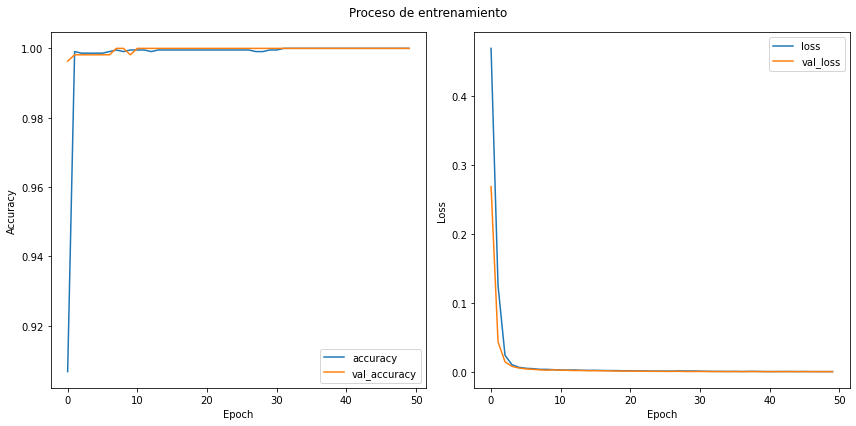

```python
# Log CSV

fig, (ax1, ax2) = plt.subplots(1, 2, figsize=(12, 6))
plt.suptitle('Proceso de entrenamiento')
history = pd.read_csv(log_csv)
history[['accuracy', 'val_accuracy']].plot(ylabel='Accuracy', ax=ax1, xlabel='Epoch')
history[['loss', 'val_loss']].plot(ylabel='Loss', ax=ax2, xlabel='Epoch')
plt.tight_layout()
plt.show()
```

### Conclusiones

Se realiza la revisión de canalización para hacer más eficiente el entrenamiento de la imagen. En este ejemplo se muesta el wrapper de Skilearn y Keras